# Probabilidad e Inferencia Estadística

Jeisson Rodriguez Rodriguez

2024-09-15

A continuación se presentan un problema de probabilidad e inferencia estadística, el problema determina las propiedades para algunos estimadores dados.

## PROBLEMA 2 - PROPIEDADES DE LOS ESTIMADORES

La simulación ayuda a entender y validad las propiedades de los estimadores estadísticos como son, insesgadez, eficiencia y la consistencia principalmente. El siguiente problema permite evidenciar las principales características de un grupo de estimadores propuestos para la estimación de un parámetro asociado a un modelo de probabilidad.

Sean $\ X_{1},X_{2},X_{3}$ y $\ X_{4}$, una muestra aleatoria de tamaño *n = 4* cuya población la conforma una distribución exponencial con parámetro $\theta$ desconocido. Determine las características de cada uno de los siguientes estimadores propuestos:

$\hat{\theta}_{1} = \frac{X_{1} + X_{2}}{6} + \frac{X_{3} + X_{4}}{3}$

$\hat{\theta}_{2} = \frac{X_{1} + 2X_{2} + 3X_{3} + 4X_{4}}{5}$

$\hat{\theta}_{3} = \frac{X_{1} + X_{2} + X_{3} + X_{4}}{4}$

$\hat{\theta}_{4} = \frac{min\left\{X_{1},X_{2},X_{3},X_{4}\right\} + max\left\{X_{1},X_{2},X_{3},X_{4} \right\}}{2}$

## SOLUCIÓN

```r
n <- 20 #tamaño de la muestra
cant.muestras <- 100 # cantidad de muestras
parametro <- 2 # parámetro

D.exp <- rexp(n*cant.muestras, rate=2)
```

después organizamos los datos en una matriz de donde cada columna pertenece a una muestra *(total=100)*:

```r
Datos <- matrix(D.exp,ncol=cant.muestras)
```

seguidamente se crean los vectores donde se almacenarán los resultados de los 4 estimadores *(Longitud = 100)*:

```r
Estimador1 <- numeric(cant.muestras)
Estimador2 <- numeric(cant.muestras)
Estimador3 <- numeric(cant.muestras)
Estimador4 <- numeric(cant.muestras)
```

Ahora, se ajustan los estimadores para la muestra *(n=20)*:

```r
for ( i in 1:cant.muestras){
  Datos1 <- Datos[1:n,i]

  #------------------------------------------------------------
  # theta 1

  theta1 <- sum(Datos1[1:(n/2)])/6 + sum(Datos1[((n/2)+1):n])/3
  Estimador1[i] <- theta1

  #------------------------------------------------------------
  # theta 2

  V1 = NULL
  V2 = NULL
  for ( J in 1:n){
     V1 = (J) * (Datos1[J])
     V2 <- c(V2,V1)
  }

  theta2 <- sum(V2)/5
  Estimador2[i] <- theta2

  #------------------------------------------------------------
  # theta 3

  theta3 <- sum(Datos1)/n

  Estimador3[i] <- theta3


  #------------------------------------------------------------
  # theta 4

  theta4 <- (min(Datos1) + max(Datos1))/2

  Estimador4[i] <- theta4

}
```

Después, realizamos el boxplot de cada uno de los estimadores:

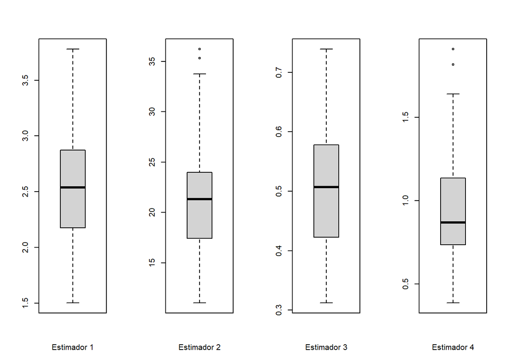

```r
par(mfrow= c(1,4))

boxplot(Estimador1,xlab = "Estimador 1")

boxplot(Estimador2,xlab = "Estimador 2")

boxplot(Estimador3,xlab = "Estimador 3")

boxplot(Estimador4,xlab = "Estimador 4")
```

Ahora, determinamos la media, el sesgo y la varianza de cada uno de los estimadores:

```r
media1 <- mean(Estimador1)
sesgo1 <- abs(2-media1)
var1 <- var(Estimador1)

media2 <- mean(Estimador2)
sesgo2 <- abs(2-media2)
var2 <- var(Estimador2)

media3 <- mean(Estimador3)
sesgo3 <- abs(2-media3)
var3 <- var(Estimador3)

media4 <- mean(Estimador4)
sesgo4 <- abs(2-media4)
var4 <- var(Estimador4)
```

Finalmente, resumimos dicha información en la siguiente matriz:

```r
x <- c(media1,media2,media3,media4,sesgo1,sesgo2,sesgo3,sesgo4,var1,var2,var3,var4)

t <- matrix(x,nrow = 4 , ncol = 3)

x1 <- c("teta1","teta2","teta3","teta4")
x2 <- c("Media de Los Estimadores","Sesgo","Varianza")

row.names(t) <- x1
colnames(t) <- x2

print(t)
```

```
##       Media de Los Estimadores     Sesgo    Varianza
## teta1                2.5352590  0.535259  0.34159479
## teta2               21.5035922 19.503592 31.18102344
## teta3                0.5064545  1.493545  0.01133672
## teta4                0.9457375  1.054263  0.09612071
```

Acá inicialmente para el tamaño de muestra **n=20** se puede visualizar que el estimador más insesgado es el **estimador 1**, pues es el que más se acerca al parámetro $\theta$, aunque el de mínima varianza es el estimador 3.

Ahora presentamos el código generalizado para ingresar el tamaño de las muestras, la cantidad de muestras y el parámetro. Esto es:

```r
GenerarEstimadores <- function(n,cant.muestras,parametro){

  D.exp <- rexp(n*cant.muestras, rate=parametro)

  Datos <- matrix(D.exp,ncol=cant.muestras)

  Estimador1 <- numeric(cant.muestras)
  Estimador2 <- numeric(cant.muestras)
  Estimador3 <- numeric(cant.muestras)
  Estimador4 <- numeric(cant.muestras)

  for ( i in 1:cant.muestras){
    Datos1 <- Datos[1:n,i]

    #------------------------------------------------------------
    # theta 1

    theta1 <- sum(Datos1[1:(n/2)])/6 + sum(Datos1[((n/2)+1):n])/3
    Estimador1[i] <- theta1

    #------------------------------------------------------------
    # theta 2

    V1 = NULL
    V2 = NULL
    for ( J in 1:n){
      V1 = (J) * (Datos1[J])
      V2 <- c(V2,V1)
      }
    theta2 <- sum(V2)/5
    Estimador2[i] <- theta2

    #------------------------------------------------------------
    # theta 3

    theta3 <- sum(Datos1)/n

    Estimador3[i] <- theta3

    #------------------------------------------------------------
    # theta 4

    theta4 <- (min(Datos1) + max(Datos1))/2

    Estimador4[i] <- theta4
    }

  par(mfrow= c(1,4))
  boxplot(Estimador1,xlab = "Estimador 1")

  boxplot(Estimador2,xlab = "Estimador 2")

  boxplot(Estimador3,xlab = "Estimador 3")

  boxplot(Estimador4,xlab = "Estimador 4")

  media1 <- mean(Estimador1)
  sesgo1 <- abs(2-media1)
  var1 <- var(Estimador1)

  media2 <- mean(Estimador2)
  sesgo2 <- abs(2-media2)
  var2 <- var(Estimador2)

  media3 <- mean(Estimador3)
  sesgo3 <- abs(2-media3)
  var3 <- var(Estimador3)

  media4 <- mean(Estimador4)
  sesgo4 <- abs(2-media4)
  var4 <- var(Estimador4)

  x <- c(media1,media2,media3,media4,sesgo1,sesgo2,sesgo3,sesgo4,var1,var2,var3,var4)
  t <- matrix(x,nrow = 4 , ncol = 3)
  x1 <- c("teta1","teta2","teta3","teta4")
  x2 <- c("Media de Los Estimadores","Sesgo","Varianza")
  row.names(t) <- x1
  colnames(t) <- x2
  print(t)
}
```

Ingresamos muestras de tamaño *n = 50,100 y 1000*, con la cantidad de muestras necesarias *(ejem = 100)* y con parámetro desconocido *(ejem = 2)*. Esto es Ingresamos

*n = 50*

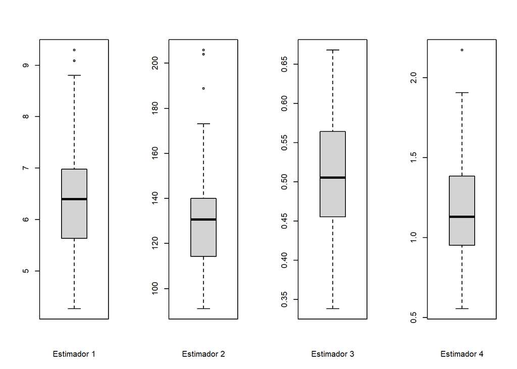

```
##       Media de Los Estimadores       Sesgo     Varianza
## teta1                6.3640776   4.3640776 9.032946e-01
## teta2              129.6799227 127.6799227 4.596481e+02
## teta3                0.5095463   1.4904537 5.067814e-03
## teta4                1.1750299   0.8249701 1.065463e-01
```

```r
GenerarEstimadores(50,100,2)
```

Se identifica que ahora el estimador más insesgado y consistente pasa a ser el **estimador 4**, pues se acerca mucho más al parámetro $\theta$, pero el de varianza mínima sigue siendo el estimador 3.

Ingresamos ahora *n = 100*

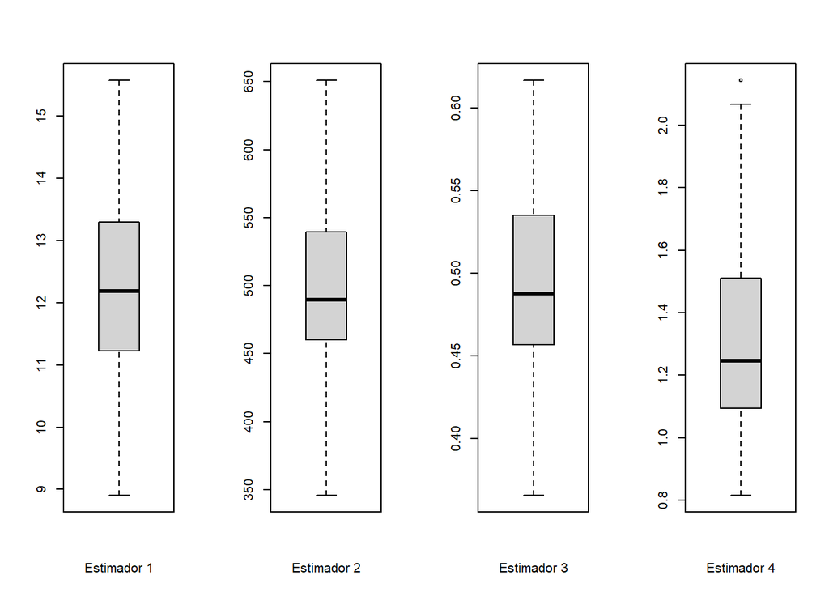

```
##       Media de Los Estimadores       Sesgo     Varianza
## teta1               12.3049557  10.3049557 1.872934e+00
## teta2              497.3647141 495.3647141 3.692157e+03
## teta3                0.4949347   1.5050653 2.739616e-03
## teta4                1.2953847   0.7046153 9.433572e-02
```

```r
GenerarEstimadores(100,100,2)
```

El estimador más insesgado y consistente sigue siendo el **estimador 4** y el de varianza mínima sigue siendo el estimador 3.

Finalmente ingresamos *n = 1000*

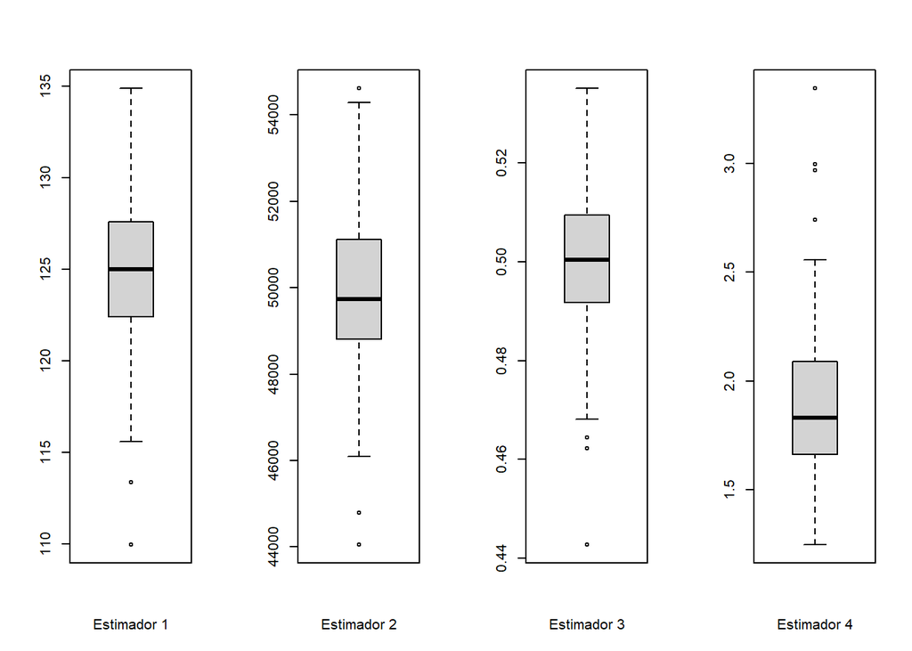

```
##       Media de Los Estimadores        Sesgo     Varianza
## teta1             1.246776e+02 1.226776e+02 1.894027e+01
## teta2             4.987213e+04 4.987013e+04 3.605032e+06
## teta3             4.995983e-01 1.500402e+00 2.556984e-04
## teta4             1.911164e+00 8.883579e-02 1.316527e-01
```

```r
GenerarEstimadores(1000,100,2)
```

Con esto concluimos finalmente que el estimador más **INSESGADO Y CONSISTENTE** para estimar el parámetro es el **ESTIMADOR 4**.